ANLT 212 - Analytics Computing  
Prof. Dana Nehoran

Python Project:  
Marketing

# Automobile Marketing Data Analysis & Prediction

By Dat Mai & Yu-Chen Hsiao

## Catalog

Exploratory Data Analysis

> **1. Objective of the Proposed Research**  
> **2. Data Exploration**  
> **3. Data Cleaning**  
> **4. Adaptation**

Visualization

> **5. Descriptive Static Visualization**

Cluster Analysis

> **6. Step-by-step hierarchical clustering**  
> **7. Dendrogram**

Unsupervised Clustering

> **8. Step-by-step K-means**  
> **9. sklearn.cluster**

Supervised Clustering

> **10. kNN Function**

Findings

> **11. Project Report**

Originality

### Preparation

```python
# Preparation for libraries
import pandas as pd
import numpy as np
import heapq
import matplotlib.pyplot as plt
import seaborn as sns
import matplotlib.patches as mpatches
from pandas import DataFrame, Series

# Set some pandas options
pd.set_option('display.max_rows', 60)
pd.set_option('display.max_columns', 60)
pd.set_option('display.width', 500)

# Preparation for matplotlib
%matplotlib inline
```

# Exploratory Data Analysis

## 1. Objective of the Proposed Research

AutoInsurance hired us to conduct the analysis about automobile industry. In this analysis, we will use the data from IBM Watson Analytics to do the research.

As part of my customer acquisition efforts, I schedule multiple appointments with the CEO to showcase my analysis depicting the most interesting facts about automobile industry.

Our main objectives are:

1. Find features that affect the company's profit most, clustering by different features such as Income, Customer Lifetime Values, Education, Gender, Sales Channel,...
2. Recommendation on what sales channel to focus on & how to improve their customers’ responses to marketing calls.

## 2. Data Exploration

```python
# Load the dataset
marketing = pd.read_csv("marketing.csv")
```

```python
# Show first 5 rows
marketing.head()
```

|  | Customer | State | Customer Lifetime Value | Response | Coverage | Education | Effective To Date | EmploymentStatus | Gender | Income | Location Code | Marital Status | Monthly Premium Auto | Months Since Last Claim | Months Since Policy Inception | Number of Open Complaints | Number of Policies | Policy Type | Policy | Renew Offer Type | Sales Channel | Total Claim Amount | Vehicle Class | Vehicle Size |
| --- | --- | --- | --- | --- | --- | --- | --- | --- | --- | --- | --- | --- | --- | --- | --- | --- | --- | --- | --- | --- | --- | --- | --- | --- |
| 0 | BU79786 | Washington | 2763.519279 | No | Basic | Bachelor | 2/24/11 | Employed | F | 56274 | Suburban | Married | 69 | 32 | 5 | 0 | 1 | Corporate Auto | Corporate L3 | Offer1 | Agent | 384.811147 | Two-Door Car | Medsize |
| 1 | QZ44356 | Arizona | 6979.535903 | No | Extended | Bachelor | 1/31/11 | Unemployed | F | 0 | Suburban | Single | 94 | 13 | 42 | 0 | 8 | Personal Auto | Personal L3 | Offer3 | Agent | 1131.464935 | Four-Door Car | Medsize |
| 2 | AI49188 | Nevada | 12887.431650 | No | Premium | Bachelor | 2/19/11 | Employed | F | 48767 | Suburban | Married | 108 | 18 | 38 | 0 | 2 | Personal Auto | Personal L3 | Offer1 | Agent | 566.472247 | Two-Door Car | Medsize |
| 3 | WW63253 | California | 7645.861827 | No | Basic | Bachelor | 1/20/11 | Unemployed | M | 0 | Suburban | Married | 106 | 18 | 65 | 0 | 7 | Corporate Auto | Corporate L2 | Offer1 | Call Center | 529.881344 | SUV | Medsize |
| 4 | HB64268 | Washington | 2813.692575 | No | Basic | Bachelor | 2/3/11 | Employed | M | 43836 | Rural | Single | 73 | 12 | 44 | 0 | 1 | Personal Auto | Personal L1 | Offer1 | Agent | 138.130879 | Four-Door Car | Medsize |

### Content

Columns:

- Customer: Customers’ ID.
- State: The customers’ location.
- Customer Lifetime Value: A prediction of the net profit attributed to the entire future relationship by a customer.
- Coverage: The plan that the customer uses.
- Education: The customers’ education.
- Effective To Date: The due date of customers’ plans.
- EmploymentStatus: The employment status of the customers.
- Gender: The customers’ gender.
- Income: The customers’ income.
- Location Code: Distinguish the customers’ location is urban, suburban or rural.
- Marital Status: The marital status of the customers.
- Monthly Premium Auto: The amount of car insurance every month.
- Months Since Last Claim: How long since the customers claim for their insurance.
- Months Since Policy Inception: How long does the customers insurance have started.
- Number of Open Complaints: Number of customers’ complaints.
- Number of Policies: How many insurance does the customer have.
- Policy Type: Personal Auto, corporate Auto or Special Auto.
- Policy: The title of insurance.
- Renew Offer Type: The type of renew offer.
- Sales Channel: The channel that the customers buy the products.
- Total Claim Amount: The sum payable at the maturity of an insurance policy of a customer.
- Vehicle Class: The class of customers’ car.
- Vehicle Size: The size of customers’ car.

```python
# Check columns names
marketing.columns
```

```
Index(['Customer', 'State', 'Customer Lifetime Value', 'Response', 'Coverage', 'Education', 'Effective To Date', 'EmploymentStatus', 'Gender', 'Income', 'Location Code', 'Marital Status', 'Monthly Premium Auto', 'Months Since Last Claim', 'Months Since Policy Inception', 'Number of Open Complaints',…
```

```python
# Check NA values
print(marketing.info())
```

```
<class 'pandas.core.frame.DataFrame'>
RangeIndex: 9134 entries, 0 to 9133
Data columns (total 24 columns):
 #   Column                         Non-Null Count  Dtype
---  ------                         --------------  -----
 0   Customer                       9134 non-null   object
 1   State                          9134 non-null   object
 2   Customer Lifetime Value        9134 non-null   float64
 3   Response                       9134 non-null   object
 4   Coverage                       9134 non-null   object
 5   Education                      9134 non-null   object
 6   Effective To Date              9134 non-null   object
 7   EmploymentStatus               9134 non-null   object
 8   Gender                         9134 non-null   object
 9   Income                         9134 non-null   int64
```

[output cut: 17 more lines]

```python
# Dataframe dimension
marketing.shape
```

```
(9134, 24)
```

There are 9,134 rows and 24 columns in dataframe.

### Sumarry the dataset

```python
# Describe data
marketing.describe()
```

|  | Customer Lifetime Value | Income | Monthly Premium Auto | Months Since Last Claim | Months Since Policy Inception | Number of Open Complaints | Number of Policies | Total Claim Amount |
| --- | --- | --- | --- | --- | --- | --- | --- | --- |
| count | 9134.000000 | 9134.000000 | 9134.000000 | 9134.000000 | 9134.000000 | 9134.000000 | 9134.000000 | 9134.000000 |
| mean | 8004.940475 | 37657.380009 | 93.219291 | 15.097000 | 48.064594 | 0.384388 | 2.966170 | 434.088794 |
| std | 6870.967608 | 30379.904734 | 34.407967 | 10.073257 | 27.905991 | 0.910384 | 2.390182 | 290.500092 |
| min | 1898.007675 | 0.000000 | 61.000000 | 0.000000 | 0.000000 | 0.000000 | 1.000000 | 0.099007 |
| 25% | 3994.251794 | 0.000000 | 68.000000 | 6.000000 | 24.000000 | 0.000000 | 1.000000 | 272.258244 |
| 50% | 5780.182197 | 33889.500000 | 83.000000 | 14.000000 | 48.000000 | 0.000000 | 2.000000 | 383.945434 |
| 75% | 8962.167041 | 62320.000000 | 109.000000 | 23.000000 | 71.000000 | 0.000000 | 4.000000 | 547.514839 |
| max | 83325.381190 | 99981.000000 | 298.000000 | 35.000000 | 99.000000 | 5.000000 | 9.000000 | 2893.239678 |

## 3. Data Cleaning

```python
df2=marketing.copy()
df2['Response'] = df2['Response'].map(dict(Yes=1, No=0))
df2['Coverage'] = df2['Coverage'].map(dict(Basic=1, Extended=2, Premium=3))
df2['Education'] = df2['Education'].replace('High School or Below', 1).replace('College', 2).replace('Bachelor', 3).replace('Master', 4).replace('Doctor', 5)
df2['Marital Status'] = df2['Marital Status'].replace('Married', 1).replace('Single', 2).replace('Divorced', 3)
df2['EmploymentStatus'] = df2['EmploymentStatus'].replace('Employed', 1).replace('Unemployed', 2).replace('Medical Leave', 3).replace('Disabled', 4).replace('Retired', 5)
df2.head()
```

|  | Customer | State | Customer Lifetime Value | Response | Coverage | Education | Effective To Date | EmploymentStatus | Gender | Income | Location Code | Marital Status | Monthly Premium Auto | Months Since Last Claim | Months Since Policy Inception | Number of Open Complaints | Number of Policies | Policy Type | Policy | Renew Offer Type | Sales Channel | Total Claim Amount | Vehicle Class | Vehicle Size |
| --- | --- | --- | --- | --- | --- | --- | --- | --- | --- | --- | --- | --- | --- | --- | --- | --- | --- | --- | --- | --- | --- | --- | --- | --- |
| 0 | BU79786 | Washington | 2763.519279 | 0 | 1 | 3 | 2/24/11 | 1 | F | 56274 | Suburban | 1 | 69 | 32 | 5 | 0 | 1 | Corporate Auto | Corporate L3 | Offer1 | Agent | 384.811147 | Two-Door Car | Medsize |
| 1 | QZ44356 | Arizona | 6979.535903 | 0 | 2 | 3 | 1/31/11 | 2 | F | 0 | Suburban | 2 | 94 | 13 | 42 | 0 | 8 | Personal Auto | Personal L3 | Offer3 | Agent | 1131.464935 | Four-Door Car | Medsize |
| 2 | AI49188 | Nevada | 12887.431650 | 0 | 3 | 3 | 2/19/11 | 1 | F | 48767 | Suburban | 1 | 108 | 18 | 38 | 0 | 2 | Personal Auto | Personal L3 | Offer1 | Agent | 566.472247 | Two-Door Car | Medsize |
| 3 | WW63253 | California | 7645.861827 | 0 | 1 | 3 | 1/20/11 | 2 | M | 0 | Suburban | 1 | 106 | 18 | 65 | 0 | 7 | Corporate Auto | Corporate L2 | Offer1 | Call Center | 529.881344 | SUV | Medsize |
| 4 | HB64268 | Washington | 2813.692575 | 0 | 1 | 3 | 2/3/11 | 1 | M | 43836 | Rural | 2 | 73 | 12 | 44 | 0 | 1 | Personal Auto | Personal L1 | Offer1 | Agent | 138.130879 | Four-Door Car | Medsize |

Response:

- Yes = 1
- No = 0

Coverage:

- Basic = 1
- Extended = 2
- Premium = 3

Education:

- High School or Below = 1
- College = 2
- Bachelor = 3
- Master = 4
- Doctor = 5

Marital Status:

- Married = 1
- Single = 2
- Divorced = 3

Employment Status:

- Employed = 1
- Unemployed = 2
- Medical Leave = 3
- Disabled = 4
- Retired = 5

## 4. Adaptation

```python
mycols = ["Customer","State",
          "Customer Lifetime Value", "Response", "Coverage", "Education", "EmploymentStatus", "Gender",
          "Income", "Location Code", "Marital Status", "Monthly Premium Auto",
          "Sales Channel", "Vehicle Class", "Vehicle Size"]
```

```python
# Dataset of people who response to a Marketing call
yes_df = df2[df2['Response'] == 1]
```

```python
yes_df = yes_df[mycols]
yes_df=yes_df.drop('Response',1)
yes_df.head()
```

|  | Customer | State | Customer Lifetime Value | Coverage | Education | EmploymentStatus | Gender | Income | Location Code | Marital Status | Monthly Premium Auto | Sales Channel | Vehicle Class | Vehicle Size |
| --- | --- | --- | --- | --- | --- | --- | --- | --- | --- | --- | --- | --- | --- | --- |
| 5 | OC83172 | Oregon | 8256.297800 | 1 | 3 | 1 | F | 62902 | Rural | 1 | 69 | Web | Two-Door Car | Medsize |
| 6 | XZ87318 | Oregon | 5380.898636 | 1 | 2 | 1 | F | 55350 | Suburban | 1 | 67 | Agent | Four-Door Car | Medsize |
| 8 | DY87989 | Oregon | 24127.504020 | 1 | 3 | 3 | M | 14072 | Suburban | 3 | 71 | Agent | Four-Door Car | Medsize |
| 13 | SJ95423 | Arizona | 8819.018934 | 1 | 1 | 1 | M | 99845 | Suburban | 1 | 110 | Branch | SUV | Medsize |
| 22 | YH23384 | Arizona | 24127.504020 | 1 | 3 | 3 | M | 14072 | Suburban | 3 | 71 | Agent | Four-Door Car | Medsize |

```python
yes_df['Customer Lifetime Value'].mean()
```

```
7854.871361325684
```

```python
# Dataset of people who not response to a Marketing call
no_df = df2[df2['Response'] == 0]
```

```python
no_df = no_df[mycols]
no_df=no_df.drop('Response',1)
no_df.head()
```

|  | Customer | State | Customer Lifetime Value | Coverage | Education | EmploymentStatus | Gender | Income | Location Code | Marital Status | Monthly Premium Auto | Sales Channel | Vehicle Class | Vehicle Size |
| --- | --- | --- | --- | --- | --- | --- | --- | --- | --- | --- | --- | --- | --- | --- |
| 0 | BU79786 | Washington | 2763.519279 | 1 | 3 | 1 | F | 56274 | Suburban | 1 | 69 | Agent | Two-Door Car | Medsize |
| 1 | QZ44356 | Arizona | 6979.535903 | 2 | 3 | 2 | F | 0 | Suburban | 2 | 94 | Agent | Four-Door Car | Medsize |
| 2 | AI49188 | Nevada | 12887.431650 | 3 | 3 | 1 | F | 48767 | Suburban | 1 | 108 | Agent | Two-Door Car | Medsize |
| 3 | WW63253 | California | 7645.861827 | 1 | 3 | 2 | M | 0 | Suburban | 1 | 106 | Call Center | SUV | Medsize |
| 4 | HB64268 | Washington | 2813.692575 | 1 | 3 | 1 | M | 43836 | Rural | 2 | 73 | Agent | Four-Door Car | Medsize |

```python
no_df['Customer Lifetime Value'].mean()
```

```
8030.022304870696
```

The higher the Customer Lifetime value is, the less likely that the customer will be response to marketing calls.

# Visualization

## 5. Descriptive Static Visualization

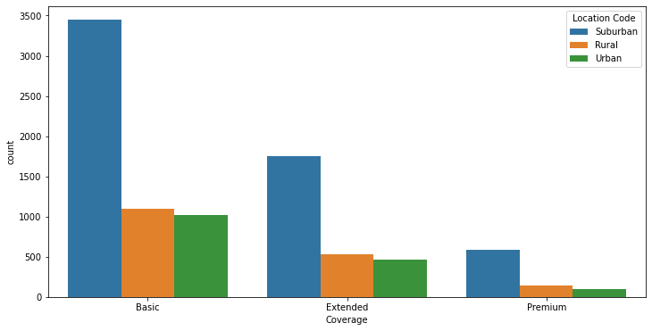

```python
plt.figure(figsize=(12,6))
ax = sns.countplot('Coverage', hue = marketing['Location Code'], data = marketing)

plt.show()
```

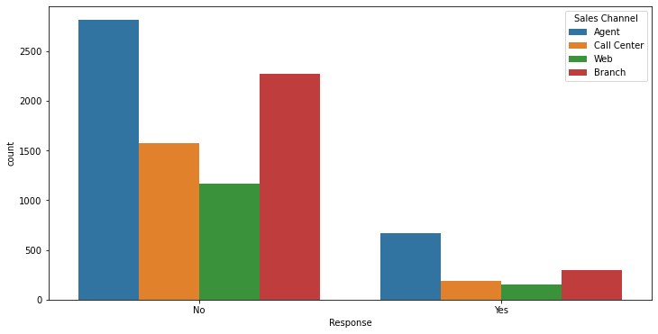

```python
plt.figure(figsize=(12,6))
ax = sns.countplot('Response', hue = marketing['Sales Channel'], data = marketing)

plt.show()
```

More people response to a marketing call if it comes from their trusted agent or branch.

### Response Source:

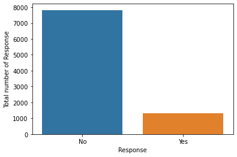

```python
ax = sns.countplot('Response',data = marketing)
plt.ylabel('Total number of Response')

plt.show()
```

Around 15% customers have responded to marketing calls, and the remaining 85% of the customers have not responded.

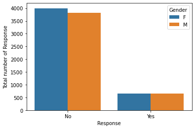

```python
ax = sns.countplot('Response',hue = 'Gender' ,data = marketing)
plt.ylabel('Total number of Response')

plt.show()
```

Ratio of male and female for responding to a marketing call is almost same.

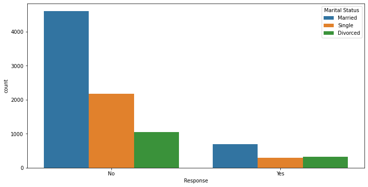

```python
plt.figure(figsize=(12,6))
ax = sns.countplot('Response', hue = marketing['Marital Status'], data = marketing)

plt.show()
```

Customers who responded to marketing calls are mostly from married category.

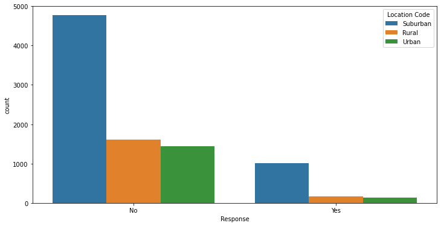

```python
plt.figure(figsize=(12,6))
ax = sns.countplot('Response', hue = marketing['Location Code'], data = marketing)

plt.show()
```

Most people response to marketing calls are from suburban area.

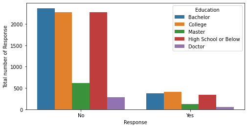

```python
plt.figure(figsize=(8,4))
ax = sns.countplot('Response',hue = 'Education' ,data = marketing)
plt.ylabel('Total number of Response')

plt.show()
```

Customers with Doctor or Master degree are very less responded to marketing calls, may be they are not interested or busy. Or we can say young people are most likely to respond to marketing calls.

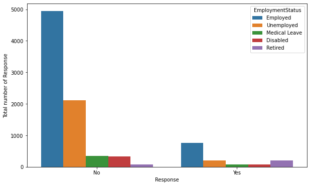

```python
plt.figure(figsize=(10,6))
ax = sns.countplot('Response',hue = 'EmploymentStatus' ,data = marketing)
plt.ylabel('Total number of Response')

plt.show()
```

Customers who responded to marketing calls are mostly from Employed category.

### Responsed - Sales Channel

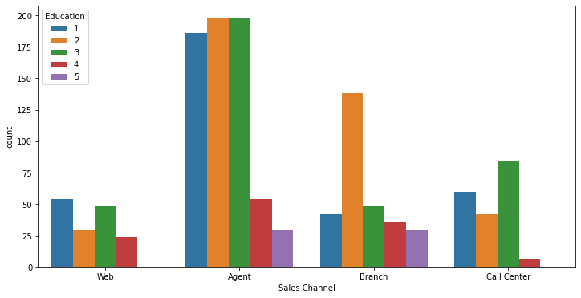

```python
plt.figure(figsize=(12,6))
ax = sns.countplot('Sales Channel', hue = yes_df['Education'], data = yes_df)

plt.show()
```

Customers with doctor degree don't response to marketing calls from Call Center and Website.

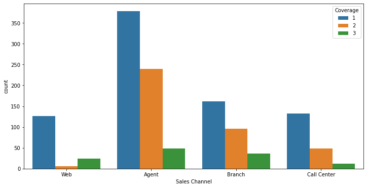

```python
plt.figure(figsize=(12,6))
ax = sns.countplot('Sales Channel', hue = yes_df['Coverage'], data = yes_df)

plt.show()
```

Agent is the best sale channel and Branch sale channel is doing very well with customers in College.

### Correlation

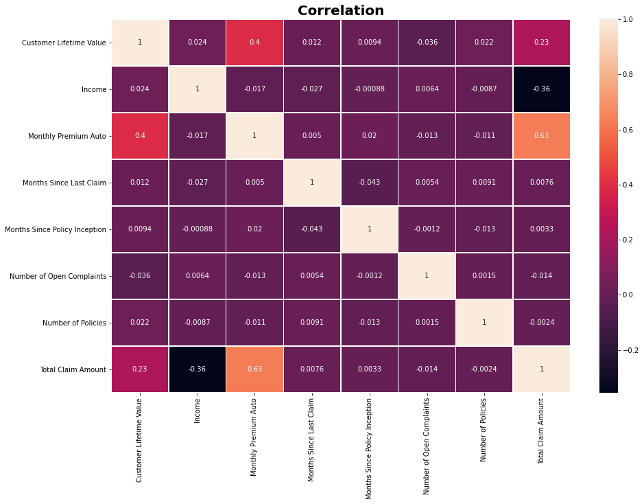

```python
# Plot data
sns.heatmap(marketing.corr(), annot = True, linewidths=0.5)
plt.gcf().set_size_inches(15, 10)

# Tiltle
plt.title('Correlation', fontsize = 20, fontweight='bold')

plt.show()
```

There are correlation between:

- Total Claim Amount & Monthly Premium Auto
- Monthly Premium Auto & CLV

### Sales Channel vs Customer Lifetime Value (CLV)

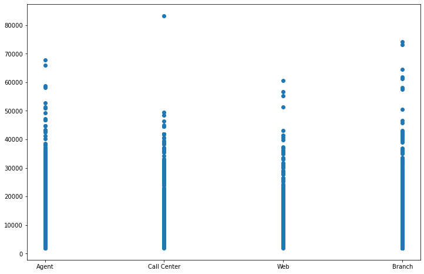

```python
fig, ax = plt.subplots(figsize=(12, 8))

ax.scatter(marketing["Sales Channel"], marketing["Customer Lifetime Value"])
```

Call Center is not performing well compared to other channels.

### State vs CLV

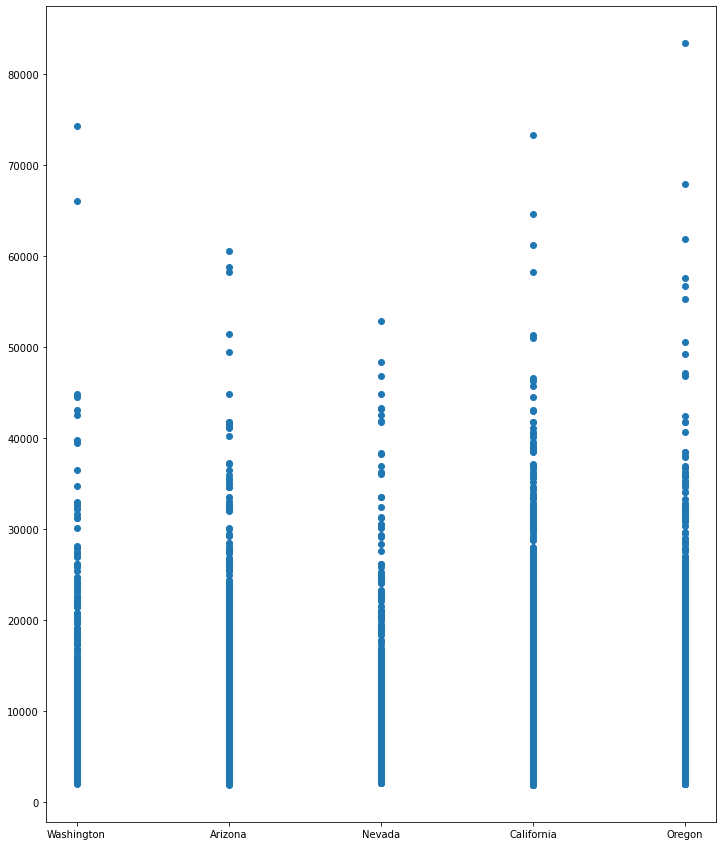

```python
fig, ax = plt.subplots(figsize=(12, 15))

ax.scatter(marketing["State"], marketing["Customer Lifetime Value"])
```

California customers are more valuable.

### Vehicle Class vs CLV

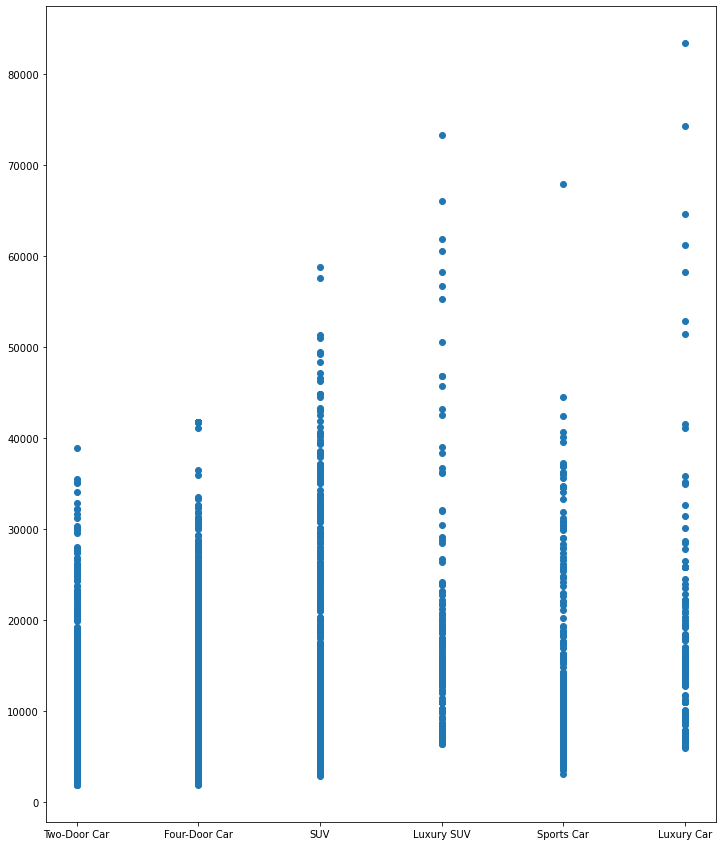

```python
fig, ax = plt.subplots(figsize=(12, 15))

ax.scatter(marketing["Vehicle Class"], marketing["Customer Lifetime Value"])
```

### Vehicle Size vs CLV

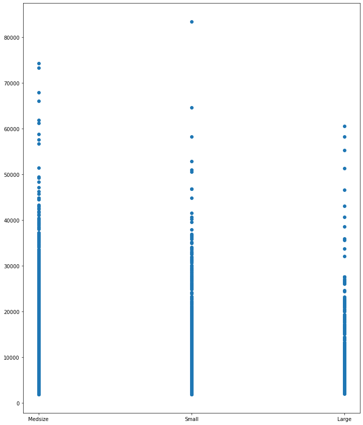

```python
fig, ax = plt.subplots(figsize=(12, 15))

ax.scatter(marketing["Vehicle Size"], marketing["Customer Lifetime Value"])
```

Customers with Mid Size vehicle are adding more values.

### Policy Type vs CLV

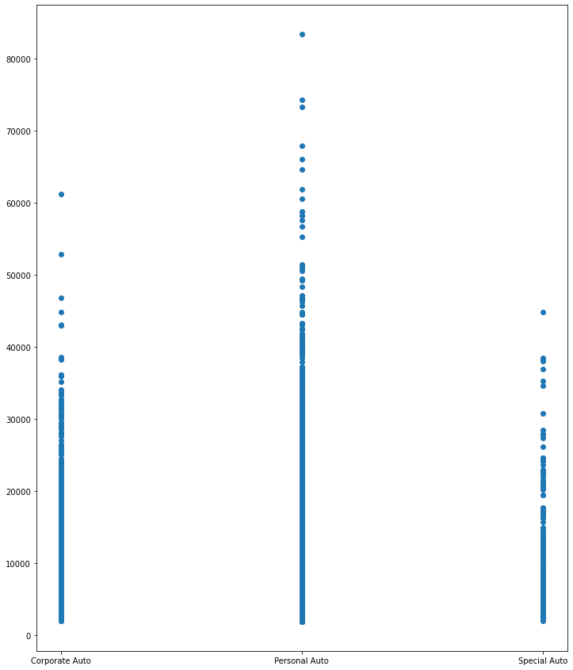

```python
fig, ax = plt.subplots(figsize=(12, 15))

ax.scatter(marketing["Policy Type"], marketing["Customer Lifetime Value"])
```

Personal Auto is more valuable.

# Cluster Analysis

## 6. Step-by-step hierarchical clustering

```python
mycols2 = ['Customer','Coverage', 'Education', 'EmploymentStatus', 'Marital Status']
```

```python
yes_df = yes_df[mycols2]
yes_df = yes_df.set_index('Customer')
yes_df
```

| Customer | Coverage | Education | EmploymentStatus | Marital Status |
| --- | --- | --- | --- | --- |
| OC83172 | 1 | 3 | 1 | 1 |
| XZ87318 | 1 | 2 | 1 | 1 |
| DY87989 | 1 | 3 | 3 | 3 |
| SJ95423 | 1 | 1 | 1 | 1 |
| YH23384 | 1 | 3 | 3 | 3 |
| ... | ... | ... | ... | ... |
| RA89822 | 1 | 1 | 1 | 1 |
| YX35990 | 1 | 4 | 1 | 1 |
| FH43628 | 2 | 2 | 5 | 2 |
| WZ45103 | 2 | 3 | 2 | 1 |
| PK87824 | 2 | 2 | 1 | 3 |

1308 rows × 4 columns

```python
from sklearn.metrics.pairwise import euclidean_distances
yes_distance_df = DataFrame(euclidean_distances(yes_df))
yes_distance_df.astype(int)
```

|  | 0 | 1 | 2 | 3 | 4 | 5 | 6 | 7 | 8 | 9 | 10 | 11 | 12 | 13 | 14 | 15 | 16 | 17 | 18 | 19 | 20 | 21 | 22 | 23 | 24 | 25 | 26 | 27 | 28 | … |
| --- | --- | --- | --- | --- | --- | --- | --- | --- | --- | --- | --- | --- | --- | --- | --- | --- | --- | --- | --- | --- | --- | --- | --- | --- | --- | --- | --- | --- | --- | --- |
| 0 | 0 | 1 | 2 | 2 | 2 | 1 | 1 | 2 | 4 | 2 | 2 | 2 | 4 | 1 | 1 | 1 | 1 | 2 | 5 | 4 | 2 | 2 | 2 | 4 | 2 | 4 | 2 | 2 | 1 | … |
| 1 | 1 | 0 | 3 | 1 | 3 | 1 | 1 | 2 | 4 | 2 | 2 | 1 | 4 | 1 | 1 | 1 | 1 | 2 | 4 | 4 | 1 | 2 | 1 | 4 | 2 | 4 | 1 | 1 | 1 | … |
| 2 | 2 | 3 | 0 | 3 | 0 | 2 | 3 | 2 | 2 | 1 | 2 | 3 | 3 | 3 | 3 | 2 | 1 | 3 | 3 | 2 | 3 | 3 | 3 | 3 | 1 | 2 | 2 | 3 | 3 | … |
| 3 | 2 | 1 | 3 | 0 | 3 | 1 | 2 | 2 | 4 | 3 | 2 | 1 | 4 | 1 | 2 | 1 | 1 | 2 | 4 | 4 | 1 | 2 | 0 | 4 | 2 | 4 | 1 | 1 | 2 | … |
| 4 | 2 | 3 | 0 | 3 | 0 | 2 | 3 | 2 | 2 | 1 | 2 | 3 | 3 | 3 | 3 | 2 | 1 | 3 | 3 | 2 | 3 | 3 | 3 | 3 | 1 | 2 | 2 | 3 | 3 | … |
| ... | ... | ... | ... | ... | ... | ... | ... | ... | ... | ... | ... | ... | ... | ... | ... | ... | ... | ... | ... | ... | ... | ... | ... | ... | ... | ... | ... | ... | ... | … |
| 1303 | 2 | 1 | 3 | 0 | 3 | 1 | 2 | 2 | 4 | 3 | 2 | 1 | 4 | 1 | 2 | 1 | 1 | 2 | 4 | 4 | 1 | 2 | 0 | 4 | 2 | 4 | 1 | 1 | 2 | … |
| 1304 | 1 | 2 | 3 | 3 | 3 | 2 | 1 | 2 | 4 | 2 | 2 | 3 | 4 | 2 | 1 | 2 | 2 | 2 | 5 | 4 | 3 | 3 | 3 | 4 | 3 | 4 | 3 | 3 | 1 | … |
| 1305 | 4 | 4 | 2 | 4 | 2 | 4 | 4 | 4 | 1 | 3 | 4 | 4 | 1 | 4 | 4 | 3 | 3 | 4 | 1 | 1 | 3 | 3 | 4 | 1 | 3 | 1 | 3 | 4 | 4 | … |
| 1306 | 1 | 1 | 2 | 2 | 2 | 2 | 1 | 2 | 3 | 2 | 2 | 2 | 3 | 1 | 1 | 1 | 1 | 1 | 4 | 3 | 2 | 1 | 2 | 3 | 2 | 3 | 2 | 2 | 1 | … |
| 1307 | 2 | 2 | 2 | 2 | 2 | 1 | 2 | 1 | 4 | 1 | 1 | 1 | 4 | 2 | 2 | 2 | 1 | 2 | 4 | 4 | 2 | 2 | 2 | 4 | 1 | 4 | 2 | 1 | 2 | … |

1308 rows × 1308 columns

```python
from scipy.cluster.hierarchy import dendrogram, linkage, leaves_list
Z = linkage(yes_df, 'average')
Z
```

```
array([[0.00000000e+00, 4.30000000e+01, 0.00000000e+00, 2.00000000e+00],
       [1.00000000e+00, 6.70000000e+01, 0.00000000e+00, 2.00000000e+00],
       [2.00000000e+00, 4.00000000e+00, 0.00000000e+00, 2.00000000e+00],
       ...,
       [2.60900000e+03, 2.61000000e+03, 2.62814302e+00, 9.78000000e+02],
       [2.60800000e+03, 2.61100000e+03, 2.82351280e+00, 3.30000000e+02],
       [2.61200000e+03, 2.61300000e+03, 3.86588981e+00, 1.30800000e+03]])
```

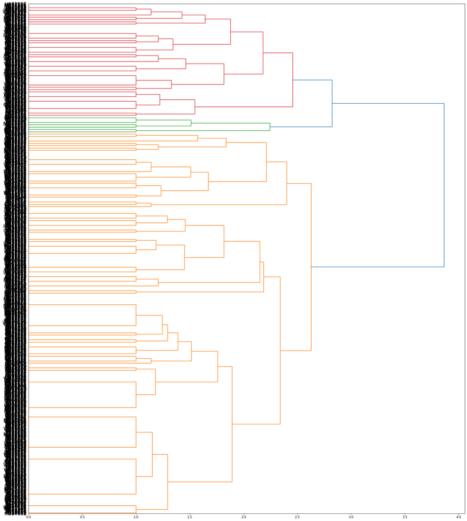

```python
from scipy.cluster.hierarchy import dendrogram, linkage, leaves_list
plt.figure(figsize=(25, 30))
D = dendrogram(Z=Z, orientation="right", leaf_font_size=15,
               labels = yes_df.index)
```

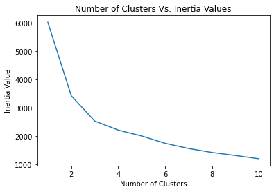

```python
from sklearn.cluster import KMeans

clusters = [1,2,3,4,5,6,7,8,9,10]
inertia_values = []
for cluster in clusters:
    k_means = KMeans(n_clusters = cluster)
    k_means.fit(yes_df)
    inertia_values.append(k_means.inertia_)

plt.plot(clusters, inertia_values)
plt.xlabel('Number of Clusters')
plt.ylabel('Inertia Value')
plt.title('Number of Clusters Vs. Inertia Values')

plt.show()
```

The elbow point is around 3 -> k =3

## 7. Dendrogram

```python
norm_customers_df = round((yes_df - yes_df.min())/
                          (yes_df.max() - yes_df.min()),2)
norm_customers_df
```

| Customer | Coverage | Education | EmploymentStatus | Marital Status |
| --- | --- | --- | --- | --- |
| OC83172 | 0.0 | 0.50 | 0.00 | 0.0 |
| XZ87318 | 0.0 | 0.25 | 0.00 | 0.0 |
| DY87989 | 0.0 | 0.50 | 0.50 | 1.0 |
| SJ95423 | 0.0 | 0.00 | 0.00 | 0.0 |
| YH23384 | 0.0 | 0.50 | 0.50 | 1.0 |
| ... | ... | ... | ... | ... |
| RA89822 | 0.0 | 0.00 | 0.00 | 0.0 |
| YX35990 | 0.0 | 0.75 | 0.00 | 0.0 |
| FH43628 | 0.5 | 0.25 | 1.00 | 0.5 |
| WZ45103 | 0.5 | 0.50 | 0.25 | 0.0 |
| PK87824 | 0.5 | 0.25 | 0.00 | 1.0 |

1308 rows × 4 columns

### Working with big data

Because the dataset is too large. So in order to deal with this in easy way, we wil use sampling techniques. We use sample size: 100 for easier plot and cluster.

```python
# Take 100 data as sample
sample_df = norm_customers_df.sample(100)
```

```python
from sklearn.metrics.pairwise import euclidean_distances
distance_df = DataFrame(euclidean_distances(sample_df))
distance_df.astype(int).head()
```

|  | 0 | 1 | 2 | 3 | 4 | 5 | 6 | 7 | 8 | 9 | 10 | 11 | 12 | 13 | 14 | 15 | 16 | 17 | 18 | 19 | 20 | 21 | 22 | 23 | 24 | 25 | 26 | 27 | 28 | … |
| --- | --- | --- | --- | --- | --- | --- | --- | --- | --- | --- | --- | --- | --- | --- | --- | --- | --- | --- | --- | --- | --- | --- | --- | --- | --- | --- | --- | --- | --- | --- |
| 0 | 0 | 0 | 0 | 1 | 0 | 0 | 0 | 0 | 0 | 0 | 0 | 0 | 0 | 0 | 0 | 0 | 0 | 0 | 0 | 0 | 1 | 0 | 1 | 0 | 0 | 0 | 0 | 1 | 0 | … |
| 1 | 0 | 0 | 0 | 0 | 0 | 0 | 0 | 1 | 1 | 0 | 0 | 0 | 0 | 0 | 1 | 0 | 0 | 0 | 0 | 0 | 1 | 0 | 1 | 0 | 0 | 1 | 0 | 1 | 1 | … |
| 2 | 0 | 0 | 0 | 1 | 0 | 0 | 0 | 1 | 1 | 0 | 0 | 0 | 0 | 0 | 1 | 0 | 0 | 0 | 0 | 0 | 1 | 0 | 1 | 0 | 0 | 1 | 0 | 1 | 1 | … |
| 3 | 1 | 0 | 1 | 0 | 1 | 1 | 0 | 1 | 1 | 1 | 1 | 0 | 1 | 1 | 1 | 1 | 0 | 0 | 1 | 0 | 1 | 1 | 1 | 1 | 1 | 1 | 0 | 0 | 1 | … |
| 4 | 0 | 0 | 0 | 1 | 0 | 0 | 1 | 1 | 1 | 0 | 0 | 0 | 0 | 0 | 1 | 0 | 0 | 0 | 0 | 1 | 1 | 0 | 1 | 0 | 0 | 1 | 0 | 1 | 0 | … |

5 rows × 100 columns

```python
from scipy.cluster.hierarchy import dendrogram, linkage, leaves_list
Z = linkage(sample_df, 'average')
```

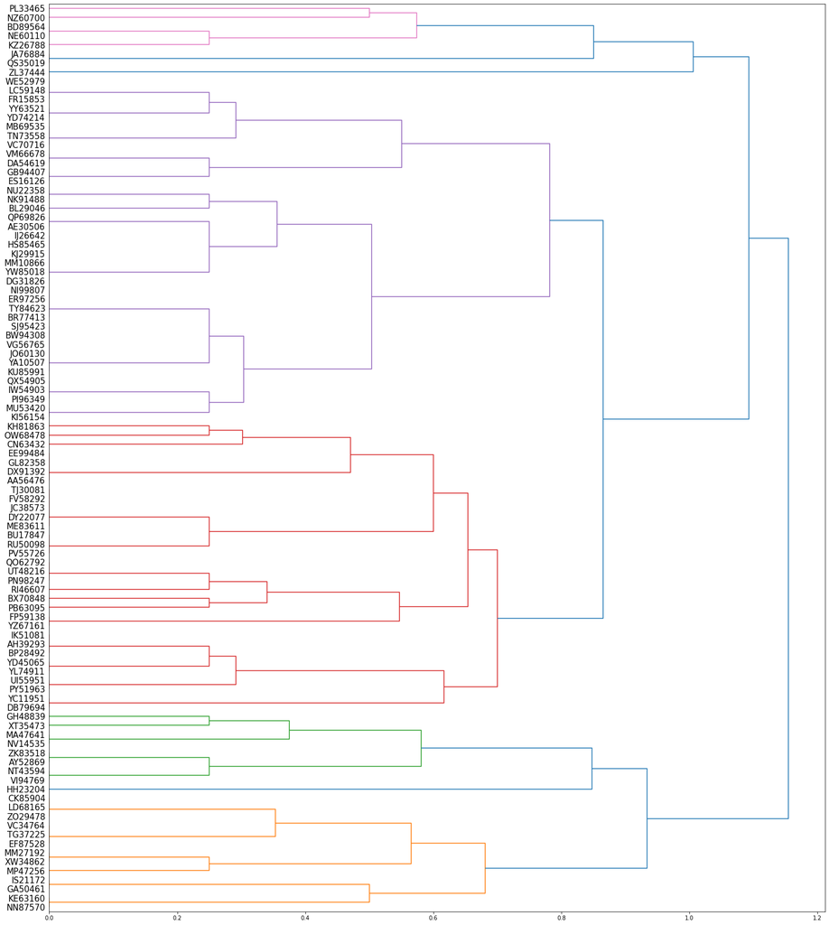

```python
plt.figure(figsize=(25, 30))
D = dendrogram(Z=Z, orientation="right", leaf_font_size=15,
               labels = sample_df.index)
```

The dendrogram looks pretty the same. So the sampling techniques is working well.

# Unsupervised Clustering

## 8. Step-by-step K-means:

```python
# Create kmeans function
class kmeans:
    def __init__(self, X, num_clusters):
        self.K = num_clusters
        self.max_iterations = 100
        self.plot_figure = True
        self.num_examples = X.shape[0]
        self.num_features = X.shape[1]

    # Establish random centroids
    def initialize_random_centroids(self, X):
        centroids = np.zeros((self.K, self.num_features))

        for k in range(self.K):
            centroid = X[np.random.choice(range(self.num_examples))]
            centroids[k] = centroid
        return centroids

    # Create clusters
    def create_clusters(self, X, centroids):

        # Will contain a list of the points that are associated with that specific cluster
        clusters = [[] for _ in range(self.K)]

        # Loop through each point and check which is the closest cluster
        for point_idx, point in enumerate(X):
            closest_centroid = np.argmin(
                np.sqrt(np.sum((point - centroids) ** 2, axis=1))
            )
            clusters[closest_centroid].append(point_idx)
        return clusters

    # Calculate new centroids
    def calculate_new_centroids(self, clusters, X):
        centroids = np.zeros((self.K, self.num_features))
        for idx, cluster in enumerate(clusters):
            new_centroid = np.mean(X[cluster], axis=0)
            centroids[idx] = new_centroid
        return centroids

    # Predict clusters
    def predict_cluster(self, clusters, X):
        y_pred = np.zeros(self.num_examples)

        for cluster_idx, cluster in enumerate(clusters):
            for sample_idx in cluster:
                y_pred[sample_idx] = cluster_idx
        return y_pred

    # Plot
    def plot_fig(self, X, y):
        plt.scatter(X[:, 0], X[:, 1], c=y, s=40, cmap=plt.cm.Spectral)
        plt.show()

    # Fit model
    def fit(self, X):
        centroids = self.initialize_random_centroids(X)

        for it in range(self.max_iterations):
            clusters = self.create_clusters(X, centroids)

            previous_centroids = centroids
            centroids = self.calculate_new_centroids(clusters, X)

            diff = centroids - previous_centroids

            if not diff.any():
                print("Satisfied Clusters Created")
                break

        # Get label predictions
        y_pred = self.predict_cluster(clusters, X)

        if self.plot_figure:
            self.plot_fig(X, y_pred)

        return y_pred
```

```python
# Run function
k = kmeans(sample_df.values, 3)
```

[output not shown]

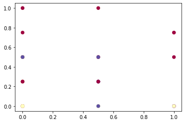

```python
# Fit and Plot
y_pred = k.fit(sample_df.values)
```

```python
y_pred
```

```
array([1., 1., 1., 0., 1., 1., 1., 2., 0., 1., 1., 1., 1., 1., 0., 0., 2.,
       2., 1., 1., 2., 1., 2., 1., 1., 0., 1., 0., 0., 1., 2., 1., 0., 1.,
       0., 0., 1., 1., 1., 0., 1., 1., 2., 0., 1., 1., 1., 0., 0., 1., 1.,
       1., 1., 2., 1., 2., 0., 0., 0., 0., 0., 0., 1., 0., 2., 1., 0., 1.,
       2., 1., 1., 1., 1., 1., 0., 1., 0., 1., 1., 1., 1., 1., 0., 2., 2.,
       0., 1., 1., 2., 0., 0., 1., 1., 1., 0., 2., 0., 1., 1., 2.])
```

## 9. sklearn.cluster

### k = 3

```python
# K Means Cluster
from sklearn.cluster import KMeans
model = KMeans(n_clusters = 3)
model.fit(sample_df)
```

```
KMeans(n_clusters=3)
```

```python
model.labels_
```

```
array([2, 2, 2, 1, 2, 2, 2, 0, 0, 2, 2, 2, 2, 2, 0, 0, 2, 2, 2, 2, 0, 2,
       0, 2, 2, 1, 2, 1, 1, 2, 0, 2, 1, 2, 1, 1, 2, 2, 2, 0, 2, 2, 0, 1,
       2, 2, 2, 1, 1, 2, 2, 2, 2, 0, 2, 2, 1, 1, 1, 1, 1, 1, 2, 0, 0, 2,
       1, 2, 0, 2, 2, 2, 2, 2, 1, 2, 1, 2, 2, 2, 2, 2, 1, 0, 0, 0, 2, 2,
       0, 1, 1, 2, 2, 2, 0, 0, 1, 2, 2, 0], dtype=int32)
```

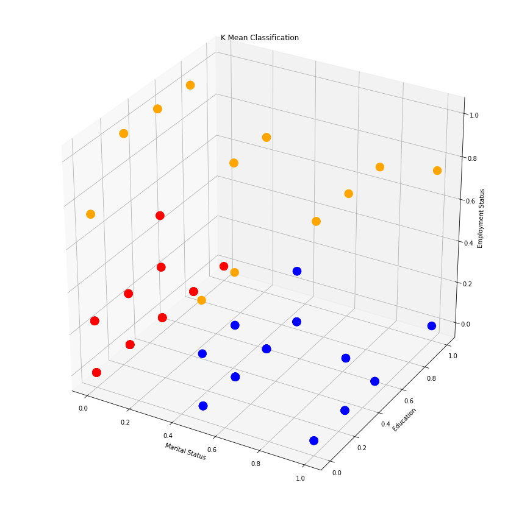

```python
# View the results
# Set the size of the plot
fig = plt.figure(figsize=(15, 15))
ax = fig.add_subplot(111, projection='3d')

# Create a colormap
colormap = np.array(['red', 'blue', 'orange'])

ax.scatter(xs = sample_df['Marital Status'], ys = sample_df.Education, zs = sample_df.EmploymentStatus, c = colormap[model.labels_],
           s = 180, depthshade = False)

plt.title('K Mean Classification')

ax.set_xlabel('Marital Status')
ax.set_ylabel('Education')
ax.set_zlabel('Employment Status')

plt.show()
```

- Orange Group: group of old people or may be people with health issues (because their current 'Employment Status' are: Unemployed, Medical Leave, Disabled or Retired)
- Red Group: group of married people and employed.
- Blue Group: group of people who are single or divorced and employed.

# Supervised Clustering

## 10. kNN Function

```python
class predictKNN:
    def __init__(self, k):
        self.k = k
        self.eps = 1e-8

    def train(self, X, y):
        self.X_train = X
        self.y_train = y

    def predict(self, X_test, num_loops=0):
        if num_loops == 0:
            distances = self.compute_distance_vectorized(X_test)

        elif num_loops == 1:
            distances = self.compute_distance_one_loop(X_test)

        else:
            distances = self.compute_distance_two_loops(X_test)

        return self.predict_labels(distances)

    def compute_distance_two_loops(self, X_test):
        num_test = X_test.shape[0]
        num_train = self.X_train.shape[0]
        distances = np.zeros((num_test, num_train))

        for i in range(num_test):
            for j in range(num_train):
                # (Taking sqrt is not necessary: min distance won't change since sqrt is monotone)
                distances[i, j] = np.sqrt(
                    self.eps + np.sum((X_test[i, :] - self.X_train[j, :]) ** 2)
                )

        return distances

    def compute_distance_one_loop(self, X_test):
        num_test = X_test.shape[0]
        num_train = self.X_train.shape[0]
        distances = np.zeros((num_test, num_train))

        for i in range(num_test):
            # (Taking sqrt is not necessary: min distance won't change since sqrt is monotone)
            distances[i, :] = np.sqrt(
                self.eps + np.sum((self.X_train - X_test[i, :]) ** 2, axis=1)
            )

        return distances

    def compute_distance_vectorized(self, X_test):
        X_test_squared = np.sum(X_test ** 2, axis=1, keepdims=True)
        X_train_squared = np.sum(self.X_train ** 2, axis=1, keepdims=True)
        two_X_test_X_train = np.dot(X_test, self.X_train.T)

        # (Taking sqrt is not necessary: min distance won't change since sqrt is monotone)
        return np.sqrt(
            self.eps + X_test_squared - 2 * two_X_test_X_train + X_train_squared.T
        )

    def predict_labels(self, distances):
        num_test = distances.shape[0]
        y_pred = np.zeros(num_test)

        for i in range(num_test):
            y_indices = np.argsort(distances[i, :])
            k_closest_classes = self.y_train[y_indices[: self.k]].astype(int)
            y_pred[i] = np.argmax(np.bincount(k_closest_classes))

        return y_pred
```

```python
# Use the results from unsupervised learning (Step-by-step K-means) as the classification - 1
y = y_pred # k=3

# k = 4
KNN = predictKNN(k=4)
KNN.train(sample_df.values, y)
y_pred2 = KNN.predict(sample_df.values, num_loops=0)
y_pred2
```

```
array([1., 2., 1., 2., 1., 1., 2., 0., 0., 1., 1., 2., 1., 1., 0., 0., 2.,
       2., 1., 2., 2., 1., 2., 1., 1., 0., 1., 0., 0., 1., 1., 1., 2., 1.,
       0., 0., 2., 2., 1., 0., 1., 1., 0., 0., 2., 1., 1., 0., 0., 1., 2.,
       1., 2., 1., 1., 2., 0., 0., 0., 0., 0., 0., 1., 0., 0., 2., 0., 2.,
       0., 2., 1., 1., 1., 1., 0., 1., 0., 1., 1., 1., 1., 1., 0., 2., 0.,
       0., 1., 1., 1., 0., 0., 1., 1., 1., 0., 0., 0., 1., 1., 1.])
```

```python
# Use the results from unsupervised learning (sklearn.cluster) as the classification - 2
y = model.labels_ # k=3

# k = 4
KNN = predictKNN(k=4)
KNN.train(sample_df.values, y)
y_pred3 = KNN.predict(sample_df.values, num_loops=0)
y_pred3
```

```
array([2., 2., 2., 1., 2., 2., 2., 0., 0., 2., 2., 2., 2., 2., 0., 1., 2.,
       2., 2., 2., 0., 2., 0., 2., 2., 1., 2., 0., 1., 2., 0., 2., 1., 2.,
       1., 1., 2., 2., 2., 0., 2., 2., 0., 1., 2., 2., 2., 1., 1., 2., 2.,
       2., 2., 0., 2., 2., 1., 1., 1., 1., 1., 1., 2., 0., 0., 2., 1., 2.,
       0., 2., 2., 2., 2., 2., 1., 2., 0., 2., 2., 2., 2., 2., 1., 0., 0.,
       0., 2., 2., 0., 1., 1., 2., 2., 2., 0., 0., 1., 2., 2., 0.])
```

```python
# Use the results from unsupervised learning as the classification - 3
y = y_pred

# k = 4
KNN = predictKNN(k=4)
KNN.train(sample_df.values, y)
y_pred4 = KNN.predict(sample_df.values, num_loops=0)
y_pred4
```

[output not shown]

```python
# Use the results from unsupervised learning as the classification - 4
y = y_pred

# k = 3
KNN = predictKNN(k=3)
KNN.train(sample_df.values, y)
y_pred5 = KNN.predict(sample_df.values, num_loops=0)
y_pred5
```

[output not shown]

```python
# Use the results from unsupervised learning as the classification - 5
y = y_pred

# k = 3
KNN = predictKNN(k=3)
KNN.train(sample_df.values, y)
y_pred6 = KNN.predict(sample_df.values, num_loops=0)
y_pred6
```

```
array([1., 1., 1., 0., 1., 1., 1., 2., 0., 1., 1., 1., 1., 1., 0., 0., 2.,
       2., 1., 1., 2., 1., 2., 1., 1., 0., 1., 0., 0., 1., 2., 1., 0., 1.,
       0., 0., 1., 1., 1., 0., 1., 1., 2., 0., 1., 1., 1., 0., 0., 1., 1.,
       1., 1., 2., 1., 1., 0., 0., 0., 0., 0., 0., 1., 0., 2., 1., 0., 1.,
       2., 0., 1., 1., 1., 1., 0., 1., 0., 1., 1., 1., 1., 1., 0., 2., 2.,
       0., 1., 1., 2., 0., 0., 1., 1., 1., 0., 2., 0., 1., 1., 2.])
```

# Findings

## 11. Project Report

### 1. Comparation between customers who response to marketing calls and who not

- The higher the Customer Lifetime value is, the less likely that the customer will be response to marketing calls.
- More people response to a marketing call if it comes from their trusted agent or branch.
- Around 15% customers have responded to marketing calls, and the remaining 85% of the customers have not responded.
- Ratio of male and female for responding to a marketing call is almost same.
- Customers who responded to marketing calls are mostly from married category.
- Most people response to marketing calls are from suburban area.
- Customers with Doctor or Master degree are very less who responded to marketing calls, may be they are not intersted or busy. Or we can say young people are most likely to respond to marketing calls.
- Customers who responded to marketing calls are mostly from Employed category.

=> Sales Channel should focus on this to optimize their time and work performance.

### 2. Sales Channel of customers who response to marekting calls vs

Education:

- Customers with doctor degree don't response to marketing calls from Call Center and Website.
- Agent is the best sale channel.
- Branch sale channel is doing very well with customers in College.

Coverage:

- Website channel is doing very well with Basic and Premium Coverage.
- Call Center channel is not performing well in Premium Coverage.

#### Recomendation based on Education and Coverage

Education:

- Hire more agents.
- List of customers with doctor degree should use to call last.
- Branch should have more marketing events suitable for College customers.

Coverage:

- Basic Coverage: share between channels.
- Extended Coverage: Agent, Branch, Call Center.
- Premium Coverage: Agent, Branch, Website.

Note: High customer lifetime value will use to call last along with list of customers with doctor degree.

### 3. Correlation

There are correlation between:

- Total Claim Amount & Monthly Premium Auto.
- Monthly Premium Auto & CLV.

This is obvious. So we do not need to mention it in this report.

### 4. Customer Lifetime Value vs

Sales Channel:

- Call Center is not performing well compared to other channels.

State:

- California customers are more valuable.

Vehicle Size:

- Customers with Mid Size vehicle are adding more values.

Policy Type:

- Personal Auto is more valuable.

#### What brings most value for AutoInsurance

There are customers bring high values for the company. So sale channel should focus on these first.

#### Future Strategy:

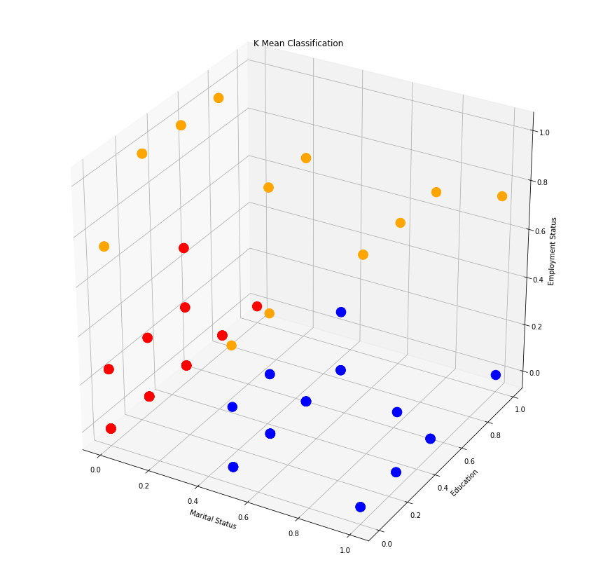

```python
# View the results
# Set the size of the plot
fig = plt.figure(figsize=(15, 15))
ax = fig.add_subplot(111, projection='3d')

# Create a colormap
colormap = np.array(['red', 'blue', 'orange'])

ax.scatter(xs = sample_df['Marital Status'], ys = sample_df.Education, zs = sample_df.EmploymentStatus, c = colormap[model.labels_],
           s = 180, depthshade = False)

plt.title('K Mean Classification')

ax.set_xlabel('Marital Status')
ax.set_ylabel('Education')
ax.set_zlabel('Employment Status')

plt.show()
```

In dataset of customers who response to marketing calls. We have 3 clusters or 3 gorups:

- Orange Group: group of old people or may be people with health issues (because their current 'Employment Status' are: Unemployed, Medical Leave, Disabled or Retired)
- Red Group: group of married people and employed.
- Blue Group: group of people who are single or divorced and employed.

#### Recommendation based on clusters:

1. Understand the need of customer: based on 3 groups, sales channel will understand what the customers want and give them exactly what they need. It might be different offer types or promotion.
2. Optimize value: designed offers for each customer segmentation to maximize received values.  
   For example: With people in Orange Group, they will have higher chances of causing accidents than normal people. So AutoInsurance might have some conditions in their contract or increase cost of insurance.
3. Customer valuations: to see if a customer is qualify for a new insurance or upgrade to another one.

# Originality

This is our original work.

- No other similar published works for clustering found with same dataset